# IODS course project

Tuomas Mäkelä

*About the project*

https://github.com/Jauhoparta/IODS-project

Getting to know R and R markdown is one of the first things I want to do as a master student of statistics. This course and the exercises should, in my view, provide a platform to try out new stuff, help others and practice writing R in real life.

In addition, learning github is a super bonus, as I have used it previously for some downloads but never for sharing work.

# Regression and model validation

The second week of the course has taken me through some data wrangling and later a little of analysis, with emphasis on graphical analysis.

## Data

```r
Learning<-read.csv("LRN14.csv")
dim(Learning)
```

```
## [1] 166   8
```

```r
str(Learning)
```

```
## 'data.frame':    166 obs. of  8 variables:
##  $ X       : int  1 2 3 4 5 6 7 8 9 10 ...
##  $ gender  : Factor w/ 2 levels "F","M": 1 2 1 2 2 1 2 1 2 1 ...
##  $ Age     : int  53 55 49 53 49 38 50 37 37 42 ...
##  $ Attitude: num  3.7 3.1 2.5 3.5 3.7 3.8 3.5 2.9 3.8 2.1 ...
##  $ deep    : num  3.58 2.92 3.5 3.5 3.67 ...
##  $ stra    : num  3.38 2.75 3.62 3.12 3.62 ...
##  $ surf    : num  2.58 3.17 2.25 2.25 2.83 ...
##  $ Points  : int  25 12 24 10 22 21 21 31 24 26 ...
```

```r
max(Learning$Points)
```

```
## [1] 33
```

```r
min(Learning$Points)
```

```
## [1] 7
```

## Graphical analysis

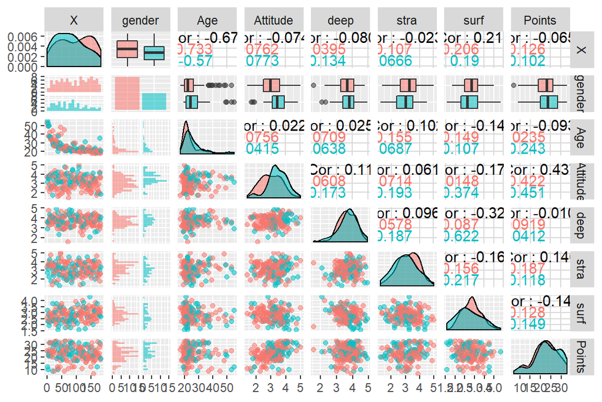

Here we see a detailed graphical representation of the data. Some interesting facts pop up, namely most of the subjects are female. The ranges and the distributions of the variables are evident, and the most interesting fact about them is that the distributions of the attitude and surf variables differ between males and females. Some of the correlations between the variables seem possibly significant, but one cannot really say based on this analysis.

## Statistical analysis

For a more detailed analysis, we fir a linear regression model onto the data. In the model we assume that the relationship of explanatory variables (here Attitude, stra and surf) explain the variable of interest (Points) in a linear manner.

```r
library(ggplot2)
library(GGally)

# create a regression model with multiple explanatory variables
my_model2 <- lm(Points ~ Attitude + stra + surf, data = Learning)

# print out a summary of the model
summary(my_model2)
```

```
##
## Call:
## lm(formula = Points ~ Attitude + stra + surf, data = Learning)
##
## Residuals:
##      Min       1Q   Median       3Q      Max
## -17.1550  -3.4346   0.5156   3.6401  10.8952
##
## Coefficients:
##             Estimate Std. Error t value Pr(>|t|)
## (Intercept)  11.0171     3.6837   2.991  0.00322 **
## Attitude      3.3952     0.5741   5.913 1.93e-08 ***
## stra          0.8531     0.5416   1.575  0.11716
## surf         -0.5861     0.8014  -0.731  0.46563
## ---
## Signif. codes:  0 '***' 0.001 '**' 0.01 '*' 0.05 '.' 0.1 ' ' 1
##
## Residual standard error: 5.296 on 162 degrees of freedom
## Multiple R-squared:  0.2074, Adjusted R-squared:  0.1927
## F-statistic: 14.13 on 3 and 162 DF,  p-value: 3.156e-08
```

The statistical test (looking at the T-values and p-values) asks if the null hypothesis that the linear coefficient corresponding to the particular explanatory variable is zero. This would mean that the variable has little or no effect on the variation of the target variable, or Points in this case.

As seen from the summary, the coefficients related to stra and surf are not statistically significant and the variables should therefore be excluded from the model.

Redoing the model, this time with only the one (significant) explanatory variable:

```r
library(ggplot2)
library(GGally)

# create a regression model with one explanatory variable
my_model2 <- lm(Points ~ Attitude, data = Learning)

# print out a summary of the model
summary(my_model2)
```

```
##
## Call:
## lm(formula = Points ~ Attitude, data = Learning)
##
## Residuals:
##      Min       1Q   Median       3Q      Max
## -16.9763  -3.2119   0.4339   4.1534  10.6645
##
## Coefficients:
##             Estimate Std. Error t value Pr(>|t|)
## (Intercept)  11.6372     1.8303   6.358 1.95e-09 ***
## Attitude      3.5255     0.5674   6.214 4.12e-09 ***
## ---
## Signif. codes:  0 '***' 0.001 '**' 0.01 '*' 0.05 '.' 0.1 ' ' 1
##
## Residual standard error: 5.32 on 164 degrees of freedom
## Multiple R-squared:  0.1906, Adjusted R-squared:  0.1856
## F-statistic: 38.61 on 1 and 164 DF,  p-value: 4.119e-09
```

The multiple R squared of the model is in this case simply the square of the regression between Attitude and Points. Since it is around 0,2, approximately 20% of the variation of points can be explained by the variation of Attitude.